# Conditioning diagnostics

Operating Model - Anchovy 9a South

María José Zúñiga

2026-06-25

# Fit stock-recruitment relationships

*Although the segmented model achieved the lowest AIC, its support relative to the Beverton–Holt model was negligible ($\Delta$AIC = 0.08). According to commonly used information-theoretic criteria, models differing by less than two AIC units receive similar empirical support. Consequently, model selection cannot be based on AIC alone.*

Comparison of alternative stock-recruitment models fitted to historical SSB-recruitment observations.

| model | logLik | AIC | delta_AIC |
| --- | --- | --- | --- |
| Beverton-Holt | 36.419 | -68.837 | 0.077 |
| Ricker | 35.915 | -67.830 | 1.085 |
| Segmented | 36.457 | -68.915 | 0.000 |

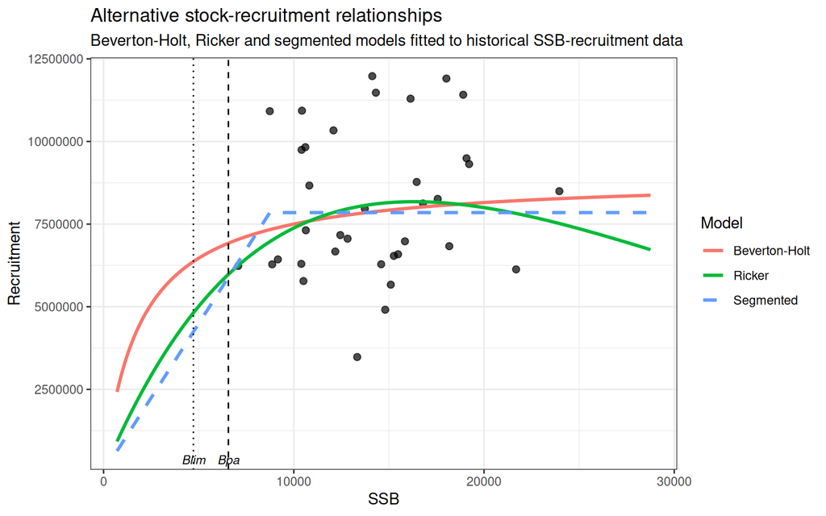

# Comparison between OM and SS3 Beverton–Holt relationships

The Beverton–Holt stock–recruitment relationship fitted in the Operating Model was compared with the Beverton–Holt relationship estimated in the SS3 assessment. The OM relationship was fitted directly to the historical SSB–recruitment pairs using the FLSR framework, whereas the SS3 relationship was derived from the assessment parameters $R_0$, steepness and unfished spawning biomass.

Across the observed biomass range, the OM predicted lower recruitment than SS3 on average, with a mean difference of 4.1%. The mean ratio between OM and SS3 predictions was 0.96, with values ranging from 0.92 to 0.98. Recruitment residuals from the two relationships were highly correlated (r = 0.999), and the mean absolute difference between residuals was 0.042 log units.

Stock-recruitment parameters used to compare the OM and SS3 Beverton-Holt relationships.

| parameter | value | source |
| --- | --- | --- |
| a_OM | 8926007.024 | FLSR OM fit |
| b_OM | 1898.343 | FLSR OM fit |
| R0_SS3 | 8291985.468 | SS3 |
| h_SS3 | 0.800 | SS3 |
| SSB0_SS3 | 17217.700 | SS3 |

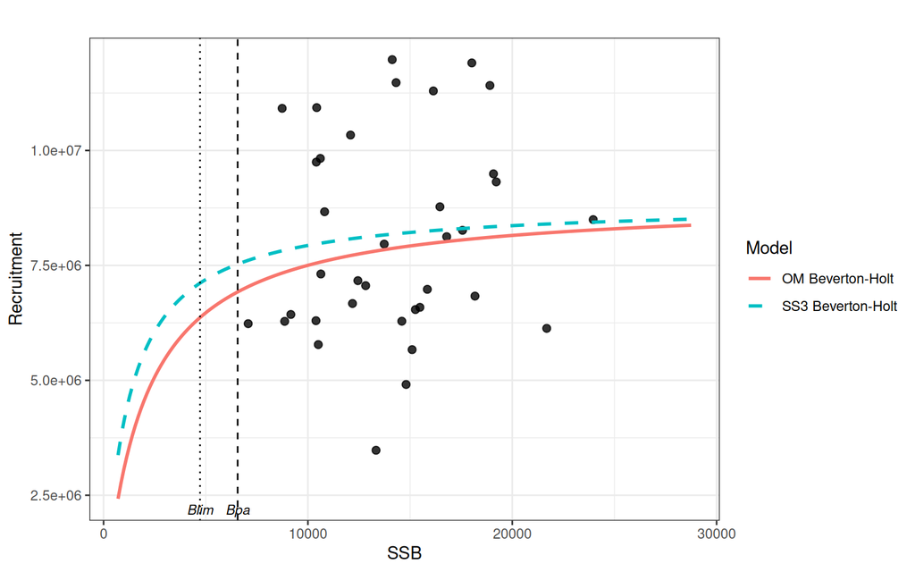

Stock-recruitment relationship. Observed recruitment, OM Beverton-Holt fit, SS3 relationship comparison

## Recruitment residual diagnostics

Recruitment residuals from the OM Beverton–Holt fit were examined to describe their distribution, temporal pattern, relationship with SSB and consistency with the recruitment process variability used in the OM.

The residuals were centred around zero, with a mean close to zero and an empirical standard deviation of 0.28. The value of $\sigma_R$ extracted from the SS3 assessment was 0.33.

Thirty-five of the 36 historical residuals (97.2%) were within the approximate 95% prediction interval defined by $\sigma_R = 0.33$. One residual was below the lower prediction limit and no residuals exceeded the upper limit.

The residual distribution showed slight negative skewness (-0.41) and kurtosis close to 3 (3.07). The Shapiro–Wilk test did not reject normality (W = 0.95, p = 0.08). Ljung–Box tests at lags 1, 3 and 5 were not significant (p = 0.46, 0.33 and 0.18, respectively).

Tail diagnostics showed that the observed lower-tail quantiles were less negative than expected under a normal distribution with $\sigma_R = 0.33$. The observed 1%, 5% and 10% quantiles were -0.69, -0.37 and -0.28, compared with expected values of -0.82, -0.60 and -0.48. The observed 95% and 99% upper-tail quantiles were 0.39 and 0.41, compared with expected values of 0.49 and 0.71.

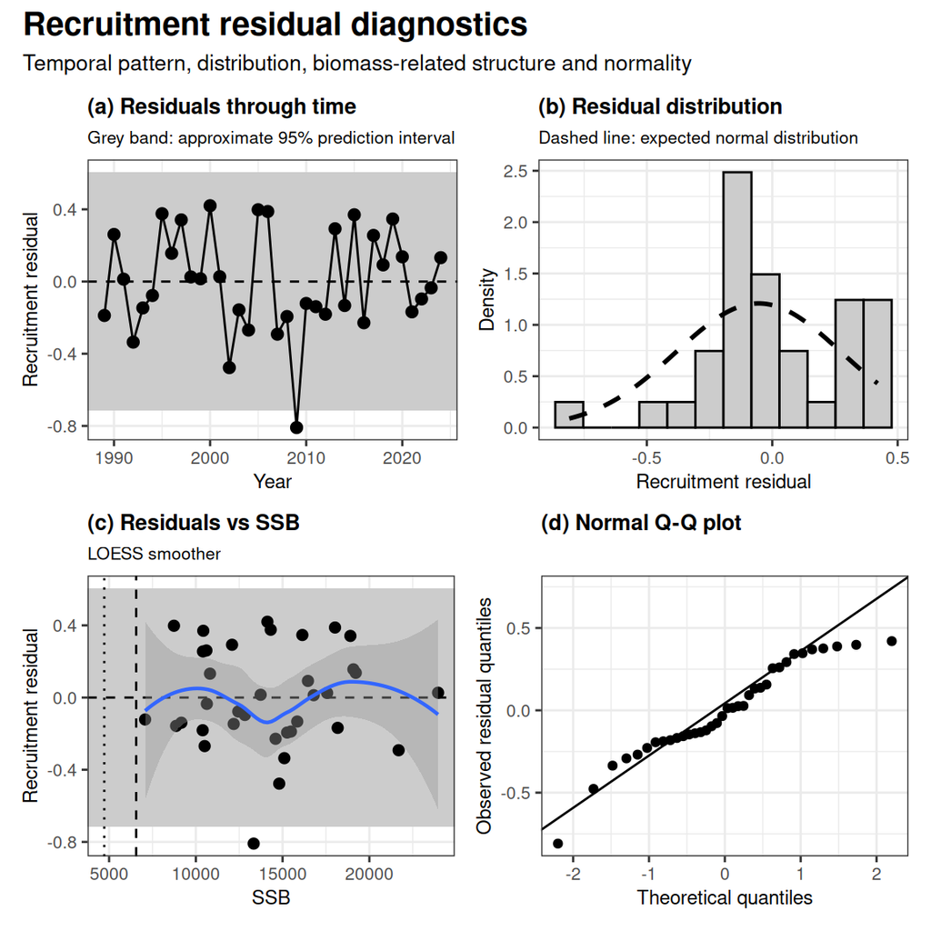

## Autocorrelation diagnostics

The ACF and PACF were used to examine temporal dependence in the OM recruitment residuals. All ACF coefficients up to lag 15 were within the approximate 95% limits. In the PACF, one coefficient at lag 5 slightly exceeded the 95% limit, while the remaining lags were within the interval.

An AR(1) model fitted to the residuals produced a low autoregressive coefficient (`ar1 = 0.12`) that was not statistically different from zero (*p* = 0.48). These results did not indicate a consistent autoregressive pattern in the recruitment residuals.

Estimated parameters of the AR(1) model fitted to recruitment residuals.

| parameter | estimate | se | z | p_value |
| --- | --- | --- | --- | --- |
| ar1 | 0.1170883 | 0.164703 | 0.7109059 | 0.4771425 |
| intercept | -0.0002140 | 0.051551 | -0.0041506 | 0.9966883 |

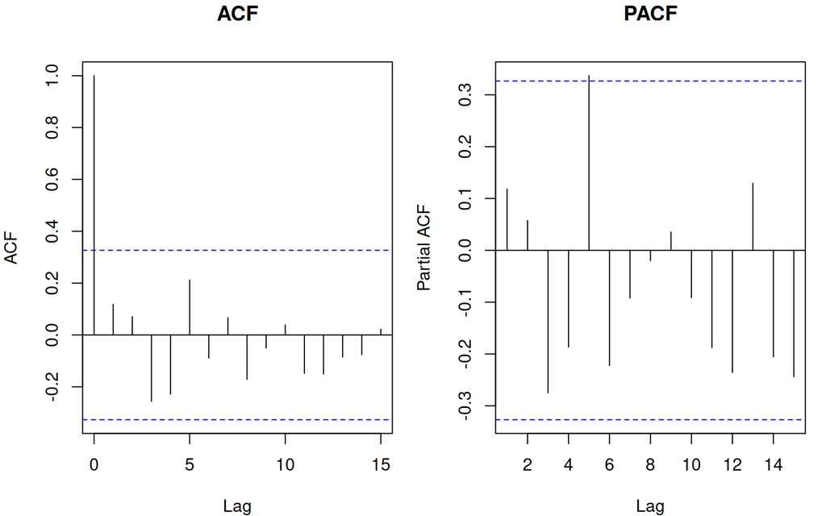

## Change-point diagnostics

Change-point analyses were applied to the historical log-recruitment series to identify potential shifts in the mean or in both the mean and variance. Using the `PELT` algorithm with the `MBIC` penalty, no change-points were detected in either the mean-only model or the mean-and-variance model.

A complementary breakpoint analysis using `strucchange` was also applied to the log-recruitment series. No finite breakpoints were retained in the resulting breakpoint table.

Overall, these diagnostics did not identify discrete changes in the historical log-recruitment series over the 1989–2024 period.

Because no changepoints were detected in the historical log-recruitment series, the full period 1989–2024 was treated as a single recruitment period. Summary statistics were therefore calculated for the complete historical series.

No changepoints were detected in the log-recruitment series using the mean-only or mean-and-variance models. Consequently, the full period 1989–2024 was retained as a single recruitment period. Mean recruitment over this period was 8.10 million recruits, with a standard deviation of 2.19 million and a geometric mean of 7.80 million.

Change-point diagnostics applied to historical log recruitment.

| method | n_change_points | change_point_index | change_point_year |
| --- | --- | --- | --- |
| mean | 0 |  |  |
| mean_and_variance | 0 |  |  |

# Recruitment temporal diagnostics

Recruitment and SSB were examined through time to evaluate temporal structure in the historical series. Since no changepoints were detected in log recruitment, the full 1989–2024 period was treated as a single recruitment period. The shaded band in panel (a) represents the mean ± SD of recruitment over the full period, and the horizontal line indicates the geometric mean.

SSB was rescaled in panel (a) only for visual comparison with recruitment. The secondary axis converts the scaled values back to the original SSB scale.

Spearman correlations were calculated between recruitment and SSB at lags from -3 to +3 years. Negative lags indicate correlations between past recruitment and current SSB, whereas positive lags indicate correlations between current SSB and future recruitment.

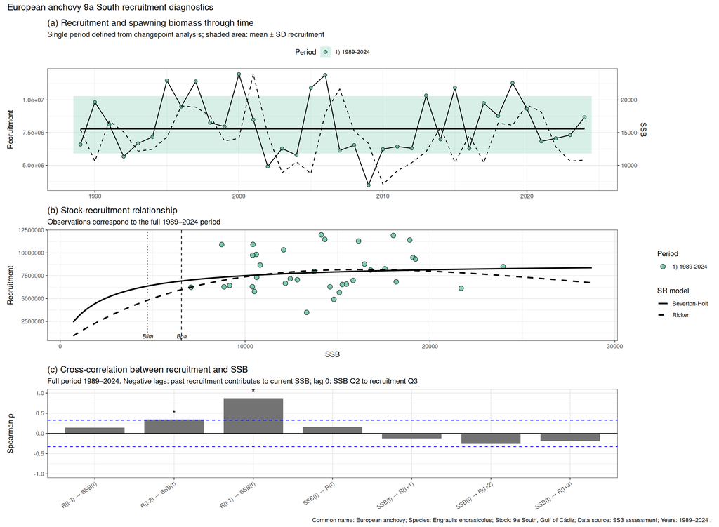

# Recruitment productivity

Formal comparisons between the historical period and the recent period showed no statistically significant differences in recruitment productivity. Neither the Welch two-sample t-test (p = 0.48) nor the Wilcoxon rank-sum test (p = 0.45) detected significant differences between periods.

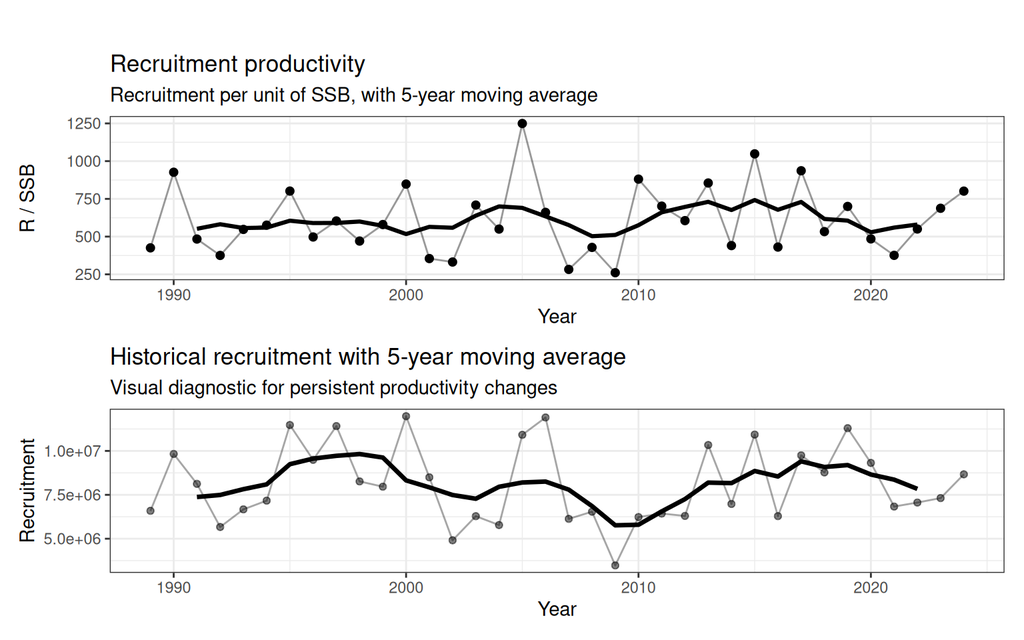

| period | 1989-2024 | 2005-present | 2015-present |
| --- | --- | --- | --- |
| mean_R | 8099228 | 8073670 | 8622617 |
| geomean_R | 7802673 | 7758343 | 8465981 |
| cv_R | 0.2706432 | 0.2778918 | 0.2011430 |
| mean_prod | 611.0144 | 645.7676 | 654.8817 |
| geomean_prod | 572.0583 | 596.1287 | 622.4046 |
| cv_prod | 0.3709503 | 0.4018972 | 0.3381180 |
| n_years | 36 | 20 | 10 |

| test | statistic | p_value |
| --- | --- | --- |
| Welch t-test | -0.7286141 | 0.4761482 |
| Wilcoxon rank-sum test | 108.0000000 | 0.4539060 |

# Density-dependence diagnostics

*The observed decline in recruitment productivity with increasing spawning biomass is consistent with compensatory recruitment dynamics. This pattern supports the use of a compensatory stock-recruitment formulation, such as the Beverton–Holt model, in the Operating Model.*

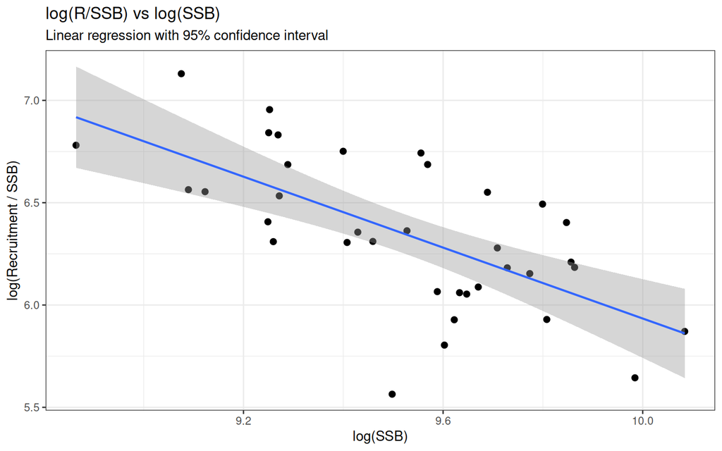

# Recruitment residual magnitude and spawning biomass

*The available historical data provide no evidence that the magnitude of recruitment deviations varies with spawning stock biomass. Therefore, recruitment process variability was represented in the Operating Model using a constant value of $\sigma_R$, rather than allowing variance to depend on stock size.*

```
## # A tibble: 1 × 6
##   test                 variable_x          variable_y statistic estimate p_value
##   <chr>                <chr>               <chr>          <dbl>    <dbl>   <dbl>
## 1 Spearman correlation |recruitment resid… SSB             8456  -0.0883   0.609
```

```
## # A tibble: 2 × 5
##   biomass_class     n mean_abs_resid median_abs_resid sd_abs_resid
##   <chr>         <int>          <dbl>            <dbl>        <dbl>
## 1 High SSB         18          0.218            0.191        0.138
## 2 Low SSB          18          0.232            0.169        0.187
```

```
## # A tibble: 1 × 4
##   test                   comparison                            statistic p_value
##   <chr>                  <chr>                                     <dbl>   <dbl>
## 1 Wilcoxon rank-sum test Absolute recruitment residuals by bi…       166   0.913
```

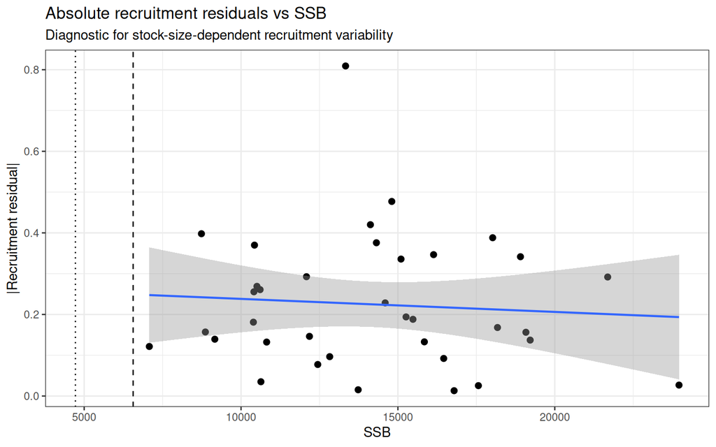

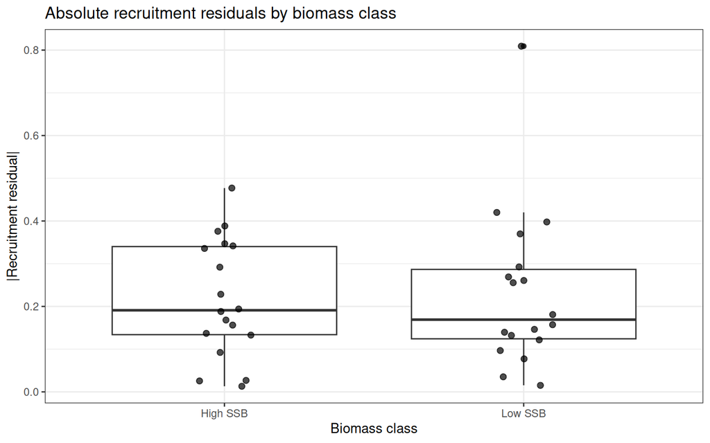

# Quarterly spawner age-structure diagnostics

This section evaluates whether the age structure of the spawning biomass in Q2 is associated with Q3 recruitment residuals. This is useful to explore spawner-age effects in the recruitment process.

Recruitment residuals from the Beverton–Holt stock–recruitment relationship were compared with three descriptors of the spawning stock age structure in quarter 2: mean spawner age, the proportion of spawning biomass contributed by age-1 fish, and the proportion contributed by fish aged 2 years and older.

Scatterplots showed recruitment residuals centred around zero across the observed range of all three explanatory variables, with no evident linear trend or systematic change in residual variability.

# Spawner age-structure diagnostics

This analysis tests whether Q3 recruitment residuals are related to the Q2 spawner age structure.

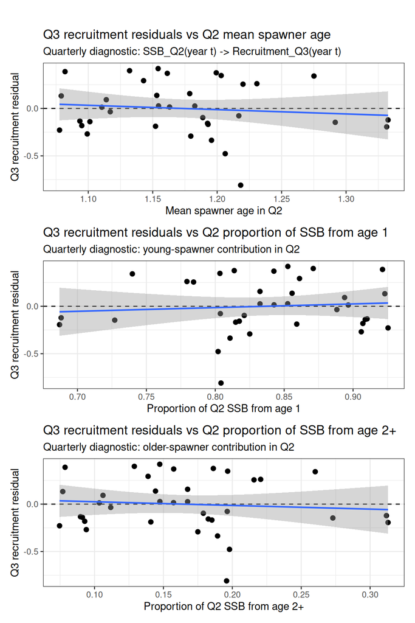

# Quarterly cohort strength diagnostics

This section classifies Q3 recruitment cohorts as strong, weak or average based on standardized log recruitment.

```
## # A tibble: 3 × 8
##   cohort_class        n mean_rec_q3 geomean_rec_q3 mean_resid_q3 median_resid_q3
##   <chr>           <int>       <dbl>          <dbl>         <dbl>           <dbl>
## 1 Average Q3 coh…    25    7672947.       7566365.       -0.0300         -0.0773
## 2 Strong Q3 coho…     7   11416400       11409817.        0.377           0.376
## 3 Weak Q3 cohort      4    4958430        4863038.       -0.473          -0.406
## # ℹ 2 more variables: mean_ssb_q2 <dbl>, median_ssb_q2 <dbl>
```

## Historical Q3 cohort strength

# Relationship between Q3 cohort strength and Q2 SSB

This analysis evaluates whether strong or weak Q3 cohorts are associated with the spawning biomass observed in Q2 of the same year.

```
## # A tibble: 3 × 6
##   cohort_class          n mean_ssb_q2 median_ssb_q2 min_ssb_q2 max_ssb_q2
##   <chr>             <int>       <dbl>         <dbl>      <dbl>      <dbl>
## 1 Average Q3 cohort    25      14214.        13733.      7076.     23960.
## 2 Strong Q3 cohort      7      14381.        14315.      8738.     18906.
## 3 Weak Q3 cohort        4      13436.        14068.     10507.     15099.
```

```
## # A tibble: 2 × 7
##   term          estimate std.error statistic p.value model        interpretation
##   <chr>            <dbl>     <dbl>     <dbl>   <dbl> <chr>        <chr>
## 1 (Intercept) -0.498     0.641        -0.777   0.443 Standardize… <NA>
## 2 ssb_q2       0.0000351 0.0000437     0.805   0.427 Standardize… No clear line…
```

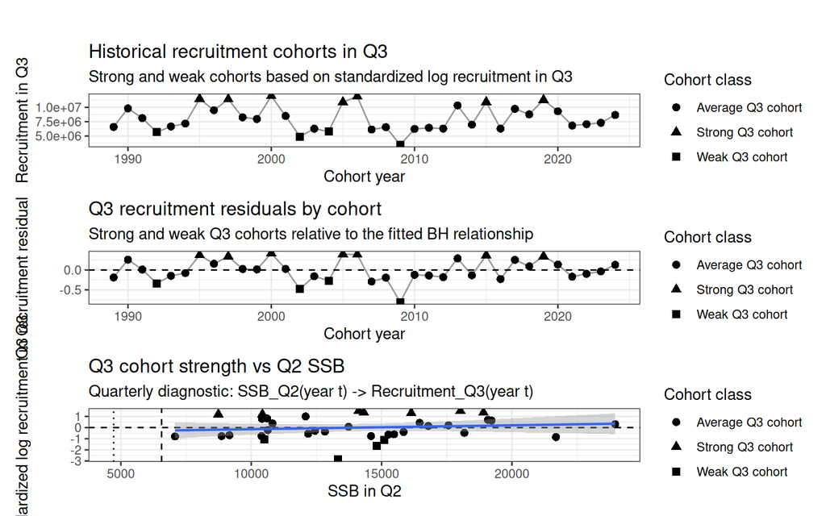